# BITE

## BITE: BioInformatics Tools for Everyone

Nowadays, molecular data analyses for biodiversity studies often require advanced bioinformatics skills, preventing many life scientists from analysing their own data autonomously. BITE R package provides complete and user-friendly functions to handle SNP data and third-party software results (i.e. Admixture, TreeMix), facilitating their visualization, interpretation and use. Furthermore, BITE implements additional useful procedures, such as representative sampling and bootstrap for TreeMix, filling the gap in existing biodiversity data analysis tools.

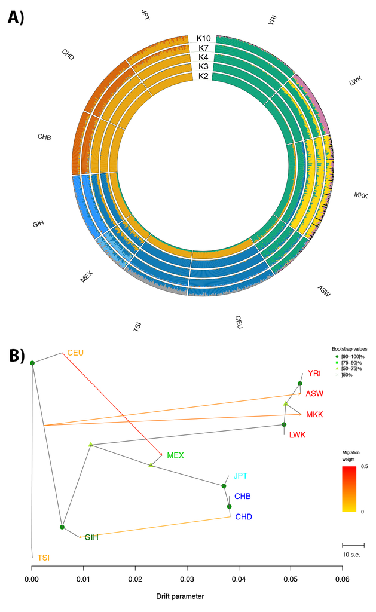

**The BITE manuscript is available at bioxriv.org.** Link to [paper](http://www.biorxiv.org/content/early/2017/08/29/181610) & [doi](https://doi.org/10.1101/181610)

### Instructions

The package could be installed from source in R. The necessary dependencies are below reported.

#### Dependencies

- RCircos (== 1.1.3)
- reshape2 (>= 1.4)
- RColorBrewer (>= 1.1)
- GenABEL (>= 1.8-0)
- car (>= 2.1-2)
- rmarkdown (>= 1.6)
- knitr (>= 1.17)
- kableExtra (>= 0.6.1)
- beanplot (>= 1.2)

##### Trouble in installation

- RCircos: you can find the correct version of the package [here](https://cran.r-project.org/src/contrib/Archive/RCircos/RCircos_1.1.3.tar.gz)
- GenABEL was archived on 2018-05-25, as [here](https://cran.r-project.org/web/packages/GenABEL/index.html) reported. However, you can istall the last available version of GenABEL following the istruction [here](https://www.reddit.com/r/rprogramming/comments/98xxna/where_to_find_dependencies_for_archived_package/) reported.

### How to cite

Milanesi, M., Capomaccio, S., Vajana, E., Bomba, L., Garcia, J.F., Ajmone-Marsan, P., Colli, L., 2017. BITE: an R package for biodiversity analyses. bioRxiv 181610. doi:10.1101/181610

### Maintainers contacts

- Marco Milanesi marco.milanesi.mm@gmail.com
- Stefano Capomaccio capemaster@gmail.com
- Elia Vajana vajana.elia@gmail.com
- Lorenzo Bomba lory.bomb@gmail.com